# Calculation of ecological condition indices

NO_IDEX_001 - for forest and mountain ecosystems

Author

Affiliation

Aud Helen Halbritter

University of Bergen

Published

July 1, 2026

Reviewed by

Anders Kolstad

> **Recommended citation**: Halbritter, A. H. 2026. Index (ID(s): NO_IDEX_001) v. 1.0.1. ecRxiv: https://github.com/NINAnor/ecRxiv/tree/main/indicators/NO_IDEX_001

**TipLog**

- 1 July 2026 - First draft of calculation
- 14 August 2026 - Renamed to NO_IDEX_001, update indicator list, imputation of missing reporting years, direct national aggregation, and update figures
- 31 August 2026 - Finalize results and figures for forest and mountain index
- 9 September 2026 - Update Norwegian indicator names, forest B3 display order, and Norwegian figure ECT legend
- 9 September 2026 - Add Norwegian national 2024 condition-scale figures for forest and mountain
- 10 September 2026 - Move mountain Warming impact on vegetation (NO_FUHR_002) from B1 to A1
- 15 September 2026 - Three-class unlabelled condition-scale bars on 2024 national figures
- 12 October 2026 - Use the newest results file for each indicator, so NO_ROED_001 contributes its published national draws, and recalculate the forest index

## 1. Aim

NO_IDEX_001 combines published ecRxiv indicator uncertainty distributions into composite indices. Version 1.0.1 contains indices for **forest** and **mountain** ecosystems, for 2019 and 2024, calculated separately by region, for ECT (Ecosystem Condition Typology) classes, and for Norway. Values near 1 indicate better ecological condition relative to reference; values toward 0 indicate deterioration.

## 2. Datasets

First, we check which indicators are included in each index and where their results can be found on ecRxiv. The overview tables at the end of this section list every matched indicator with its national (Norway) value for 2024 (median and approximate 95% interval). Indicators without published uncertainty show the point estimate only.

**Indicator lists.** Forest indicators are listed in `data/indicators_2026.csv`; mountain indicators follow [ECA_2026 #104](https://github.com/NINAnor/ECA_2026/issues/104) in `data/indicators_mountain.csv`. Each row specifies the indicator name, ecRxiv ID, and ECT class assignment.

**Source manifest.** `scan_git_indicator_sources()` searches the local `upstream` git remote (main and `submission-*` branches) for published result files (CSV, RDS, parquet) and writes `data/indicator_sources.csv`. Optional manual or fork entries can be added in `data/indicator_sources_extra.csv` if results are not yet on `upstream`. This manifest is used internally when resolving result paths; it is not shown in the document. If the scan finds few entries, run `git fetch upstream` from the project root to refresh local branch refs.

```r
# Refresh manifest from local git (upstream main + submission-* branches)
invisible(tryCatch(
  scan_git_indicator_sources(git_remote = "upstream"),
  error = function(e) invisible(NULL)
))
```

**Registry.** `build_indicator_registry()` joins the indicator lists with the manifest and probes each candidate URL or local path. Only `matched` indicators proceed to the analysis in Section 3. The tables below give an overview of matched indicators and their national (Norway) values for 2024. Full index results are reported in Section 4.1 and Section 4.2.

```r
n_sim <- 1000
n_years <- 2
report_years <- c(2014, 2019, 2024)
max_gap <- 5 # max gap in years to fill missing reporting years

registry_forest <- build_indicator_registry(
  here("data/indicators_2026.csv"),
  ecosystem = "forest",
  write_path = here("data/indicators_registry_forest.csv")
)

registry_mountain <- build_indicator_registry(
  here("data/indicators_mountain.csv"),
  ecosystem = "mountain",
  write_path = here("data/indicators_registry_mountain.csv")
)
```

```r
registry_indicator_table(
  registry_forest,
  forest_index,
  year = 2024,
  caption = "Forest indicators included in NO_IDEX_001 — Norway 2024"
)
```

Forest indicators included in NO_IDEX_001 — Norway 2024

| ECT | Indicator | ID | Median | 2.5% | 97.5% |
| --- | --- | --- | --- | --- | --- |
| A1 | Ditching | NO_AIVS_001 | 0.936 | 0.931 | 0.940 |
| A1 | Moisture impacts on vegetation | NO_FUMO_004 | 0.601 | 0.594 | 0.607 |
| A2 | Nitrogen impacts on vegetation | NO_FUNI_004 | 0.638 | 0.624 | 0.652 |
| B1 | Alien conifers | NO_AATS_002 | 0.969 | 0.966 | 0.973 |
| B1 | Alien plantspecies | NO_ALIE_004 | 0.997 | 0.995 | 0.998 |
| B1 | Bumblebees | NO_BUMB_002 | 0.606 | 0.521 | 0.682 |
| B1 | Butterflies | NO_BFLY_002 | 0.526 | 0.437 | 0.594 |
| B1 | Rowan, aspen and goat willow | NO_ROSE_001 | 0.447 | 0.413 | 0.488 |
| B1 | Total deadwood | NO_DWTO_001 | 0.159 | 0.151 | 0.166 |
| B2 | Dead wood share | NO_DTVS_001 | 0.290 | 0.273 | 0.306 |
| B2 | Large trees | NO_DLTA_001 | 0.346 | 0.332 | 0.359 |
| B2 | Multi-layered forest | NO_MLFA_001 | 0.514 | 0.499 | 0.529 |
| B3 | Bilberry cover | NO_BLAA_001 | 0.765 | 0.747 | 0.782 |
| B3 | Moose | NO_MOOS_001 | 0.544 | 0.378 | 0.714 |
| B3 | Red deer | NO_DEER_001 | 0.351 | 0.230 | 0.473 |
| B3 | Roe deer | NO_ROED_001 | 0.185 | 0.068 | 0.372 |
| B3 | Brown bear | NO_BAER_001 | 0.022 | 0.015 | 0.029 |
| B3 | Lynx | NO_LYNX_001 | 0.126 | 0.104 | 0.147 |
| B3 | Wolf | NO_WOLF_001 | 0.034 | 0.022 | 0.047 |
| C1 | Connected low-infrastructure forest habitat | NO_CONN_002 | 0.719 | NA | NA |
| C1 | Old forest | NO_BGSK_001 | 0.287 | 0.274 | 0.300 |

```r
registry_indicator_table(
  registry_mountain,
  mountain_index,
  year = 2024,
  caption = "Mountain indicators included in NO_IDEX_001 — Norway 2024"
)
```

Mountain indicators included in NO_IDEX_001 — Norway 2024

| ECT | Indicator | ID | Median | 2.5% | 97.5% |
| --- | --- | --- | --- | --- | --- |
| A1 | Glaciers | NO_GLAC_001 | 0.516 | 0.506 | 0.524 |
| A1 | Snow depth | NO_SNOW_001 | 0.884 | 0.668 | 0.966 |
| A1 | Warming impact on vegetation | NO_FUHR_002 | 0.405 | 0.385 | 0.426 |
| B1 | Alien plant species | NO_ALIE_002 | 1.000 | 0.999 | 1.000 |
| B1 | Arctic fox | NO_AFOX_001 | 0.046 | 0.034 | 0.063 |
| B1 | Golden eagle | NO_GOLD_001 | 0.892 | 0.801 | 0.967 |
| B1 | Ptarmigan | NO_PTAR_001 | 0.354 | 0.211 | 0.538 |
| B1 | Wolverine | NO_JERV_001 | 0.137 | 0.133 | 0.141 |
| B2 | Lichen biomass | NO_LAVH_001 | 0.726 | 0.715 | 0.737 |
| B3 | Erosive disturbance | NO_SLIT_001 | 1.000 | 0.977 | 1.000 |
| B3 | Small rodents | NO_RODE_001 | 0.280 | 0.259 | 0.300 |

## 3. Analyses

Forest and mountain indices are calculated separately using the same workflow (`calculate_index()` in `R/index_functions.R`). The indicator registries built in Section 2 are the input to this section.

### 3.1 Loading and harmonising indicator draws

For each `matched` indicator in the registry, `load_registry_draws()` fetches the resolved results file and harmonises it to a common structure (`year`, `part`, `value`). When several versioned results files exist for one indicator, the highest version is used. Supported source formats include:

- standard CSV (`year`, `area` or `part`/`region`, `value` or `sampled_mean`/`sampled_value`);
- period-based CSV or RDS (`period`, `area`/`region`/`region_code`, `value` or `sampled_mean`/`sampled_value`);
- regional RDS with companion national RDS (`*_mc_regional.rds` + `*_mc_national.rds`);
- parquet (`year`, `part`, `value` or `sim`).

Region labels are mapped to NI regions (`C`, `E`, `S`, `W`, `N`, `Norway`) via `data/region_lookup.csv`. Each row in the loaded data is one Monte Carlo draw for a given indicator, reporting year, and region.

### 3.2 Reporting periods

Indicators do not all use the same time axis. Some publish single calendar years (`year`); others publish multi-year **reporting periods** such as `2010-2014` or `2020-2024` (`period`). These period labels also differ between indicators (length and start/end years are not standardised).

For aggregation we map each reporting period to a single calendar year using the **period end year** (`period_to_year()`, e.g. `2020-2024` → `2024`). Where the source already provides `year`, that value is kept as is.

We use fixed national reporting years: `report_years <- c(2014, 2019, 2024)`, and retain the last `n_years` of these (`2019` and `2024` with the current settings).

Some indicators only publish one of the two retained report years — for example a first submission with only `2024` data and nothing for `2019`. For indicators that are missing one of the retained report years, `impute_missing_indicator_years()` carries its nearest other retained year’s draws forward or backward to fill the gap, so the same indicator set contributes to every reported year. This is bounded by `max_gap <- 5`: if no other retained year is within `max_gap` of the missing one, the indicator stays excluded for that year rather than being filled with a stale value. With `report_years <- c(2014, 2019, 2024)` this simply means an indicator’s nearest retained year must be within one reporting cycle (5 years) to be carried forward or backward.

### 3.3 Resampling and aggregation

Aggregation uses `ecTools::ec_upscale()` with equal weights **across indicators within an ECT class**, and **across ECT classes within the index** (`n_sim = 1000` by default). Steps 1–2 are run separately for each year and each of six areas: the five NI regions (`C`, `E`, `S`, `W`, `N`) and Norway.

Note that some indicators will have missing values for some regions. This will be describes in the workflow documentation for each indicator.

1. **Indicator → ECT** — within an area, one draw is resampled per indicator within each ECT class, then combined with equal weights to give an ECT-level draw (`aggregate_to_ect()`).
2. **ECT → index** — within the same area, one draw is resampled per ECT class, then combined with equal weights to give an overall index draw for that area (`aggregate_to_index()`).

This propagates uncertainty from individual indicators through ECT classes to the composite index without assuming independence beyond the structure encoded in the published indicator MC distributions.

No weighting is done between indicators or ECT classes: all indicators and ECT classes have equal weight (`weight = 1`). Individual indicators define their own regional weights to obtain their national estimate. Usually this weight is defined by the ecosystem extant for each region. There is one notable exception: `NO_GLAC_001`’s own published national value used the glacier area in the reference period as the regional weight, with the result of down-weighting southern Norway in the national estimate. We use these national draws as-is rather than overriding it with an equal-weight regional average.

### 3.3.1 Direct national aggregation (no ECT step)

We also calculate a direct national index that skips the ECT step: every matched indicator is resampled directly to the index with equal weight (`aggregate_indicators_to_index_direct()`), rather than first being equal-weighted within its ECT class. This means an ECT class with many indicators has proportionally more influence on this version of the index than it does in the ECT-based workflow, where each ECT class counts equally regardless of how many indicators it contains.

This direct aggregation is computed independently, and reported alongside the ECT-based index (tagged `"Index (direct)"` in the results) so the two can be compared. Note that the indicator ID NO_IDEX_001 retains to the hierarchically aggregated version.

### 3.4 Summaries

The full MC distributions (all areas) are stored for export. For reporting we summarise each ECT class and the overall index by the **median** and an approximate **95% interval** (2.5% and 97.5% quantiles). Regional and national (Norway) indices are both calculated by the same steps 1–2 above, since Norway is treated as just another area (see Section 3).

**Calculate forest index**

```r
forest_index <- calculate_index(
  registry_forest |> filter(match_status == "matched"),
  n_sim = n_sim,
  n_years = n_years,
  report_years = report_years,
  max_gap = max_gap,
  include_direct_index = TRUE
)

saveRDS(forest_index, here::here("data/forest_index_170826.rds"))
```

**Calculate mountain index**

```r
mountain_index <- calculate_index(
  registry_mountain |> filter(match_status == "matched"),
  n_sim = n_sim,
  n_years = n_years,
  report_years = report_years,
  max_gap = max_gap,
  include_direct_index = TRUE
)

saveRDS(mountain_index, here::here("data/mountain_index_170826.rds"))
```

```r
forest_index$coverage |>
  select(year, part, "# indicators" = n_indicators, "# indicators imputed" = n_indicators_imputed, "# indicators observed" = n_indicators_observed) |>
  gt::gt()
```

Table 1: Table showing the number of indicators used in the index, and how many of these were either observed or imputed.

| year | part | # indicators | # indicators imputed | # indicators observed |
| --- | --- | --- | --- | --- |
| 2019 | C | 21 | 4 | 17 |
| 2019 | E | 21 | 4 | 17 |
| 2019 | N | 19 | 4 | 15 |
| 2019 | Norway | 21 | 4 | 17 |
| 2019 | S | 21 | 4 | 17 |
| 2019 | W | 21 | 6 | 15 |
| 2024 | C | 21 | 0 | 21 |
| 2024 | E | 21 | 0 | 21 |
| 2024 | N | 19 | 0 | 19 |
| 2024 | Norway | 21 | 0 | 21 |
| 2024 | S | 21 | 0 | 21 |
| 2024 | W | 21 | 0 | 21 |

```r
# Single-indicator test: with one matched indicator, the index for any area
# (including Norway, using that indicator's own published national draws)
# equals that indicator's own draws for the same area.
if (sum(registry_mountain$match_status == "matched") >= 1) {
  one_reg <- registry_mountain |> filter(match_status == "matched") |> slice(1)
  one_out <- calculate_index(one_reg, n_sim = 200, n_years = 1, report_years = report_years, max_gap = max_gap)
  part_chk <- one_out$indicator_draws |>
    distinct(part) |>
    arrange(part) |>
    slice(1) |>
    pull(part)
  val_one <- one_out$summaries |>
    filter(level == "Index", part == part_chk) |>
    slice(1)
  src <- one_out$indicator_draws |>
    filter(part == part_chk) |>
    summarise(median = median(value), .groups = "drop")
  stopifnot(abs(val_one$median - src$median) < 0.05)
}
```

## 4. Results

Forest and mountain indices are reported separately below. Each subsection gives a full summary table (all indicators, Ecosystem Condition Typology (ECT) classes, and index totals for every area and reporting year) followed by figures.

### 4.1 Forest

```r
index_figure_summary_table(
  forest_index,
  registry_forest,
  years = target_years,
  caption = "Forest index — all areas and reporting years"
)
```

| Year | Area | Level | ECT | ID | Name | Median | 2.5% | 97.5% |
| --- | --- | --- | --- | --- | --- | --- | --- | --- |
| 2019 | C | Indicator | A1 | NO_AIVS_001 | Ditching | 0.9319934633253271 | 0.9205188245106606 | 0.9432355476133744 |
| 2019 | C | Indicator | A1 | NO_FUMO_004 | Moisture impacts on vegetation | 0.6079903149991329 | 0.595296359836321 | 0.6201672690515124 |
| 2019 | C | Indicator | A2 | NO_FUNI_004 | Nitrogen impacts on vegetation | 0.6376976653810926 | 0.613472705890278 | 0.6635441023763782 |
| 2019 | C | Indicator | B1 | NO_AATS_002 | Alien conifers | 0.9620632586764526 | 0.9536976210901791 | 0.9704088953034249 |
| 2019 | C | Indicator | B1 | NO_ALIE_004 | Alien plantspecies | 0.996915502159817 | 0.9955227948613886 | 0.9992513575221754 |
| 2019 | C | Indicator | B1 | NO_BUMB_002 | Bumblebees | 0.743116279069767 | 0.572744186046512 | 0.925837209302325 |
| 2019 | C | Indicator | B1 | NO_BFLY_002 | Butterflies | 0.459875 | 0.2948625 | 0.66625 |
| 2019 | C | Indicator | B1 | NO_ROSE_001 | Rowan, aspen and goat willow | 0.4062745214316167 | 0.3315531795544473 | 0.479436158488214 |
| 2019 | C | Indicator | B1 | NO_DWTO_001 | Total deadwood | 0.1593799890960674 | 0.1463991139975973 | 0.1741619873049812 |
| 2019 | C | Indicator | B2 | NO_DTVS_001 | Dead wood share | 0.2979778880330849 | 0.2746501090635929 | 0.3208455488175448 |

[output cut: 334 more lines]

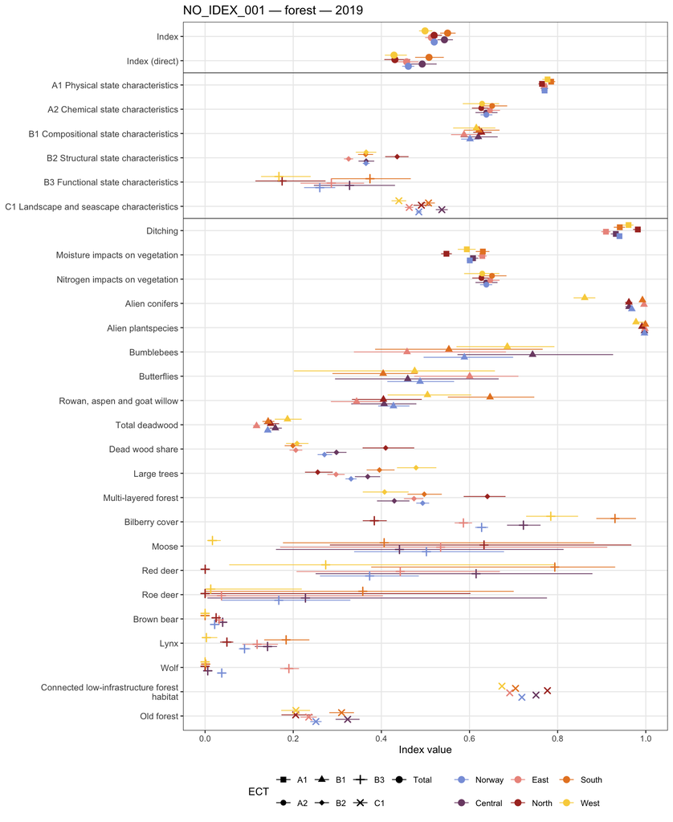

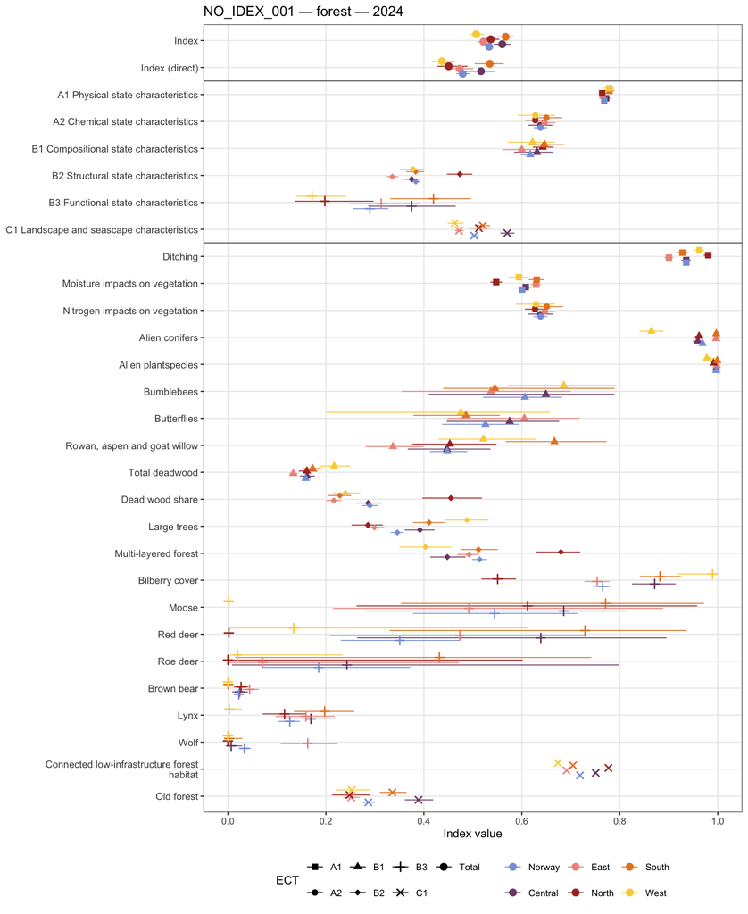

```r
for (yr in target_years) {
  print(plot_index_detailed(
    forest_index, yr,
    title = "NO_IDEX_001 — forest",
    registry = registry_forest
  ))
}
```

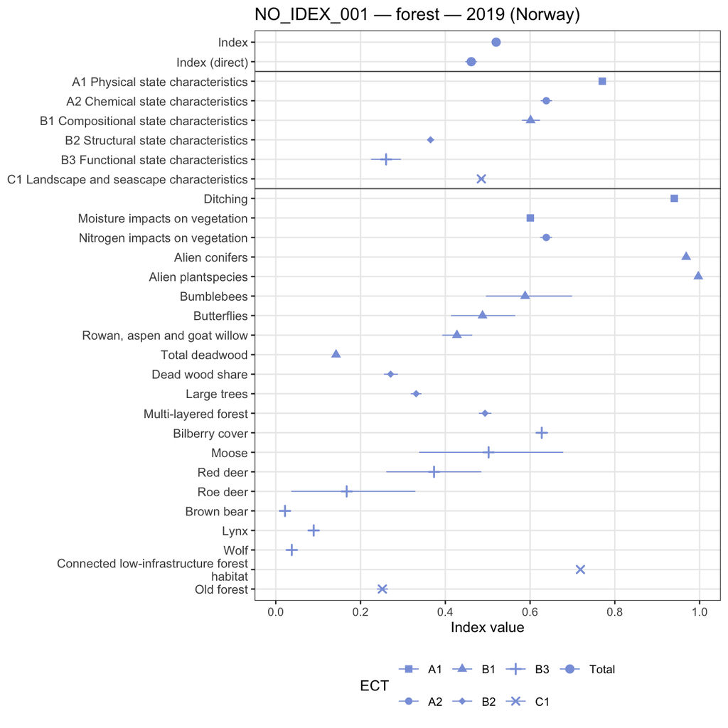

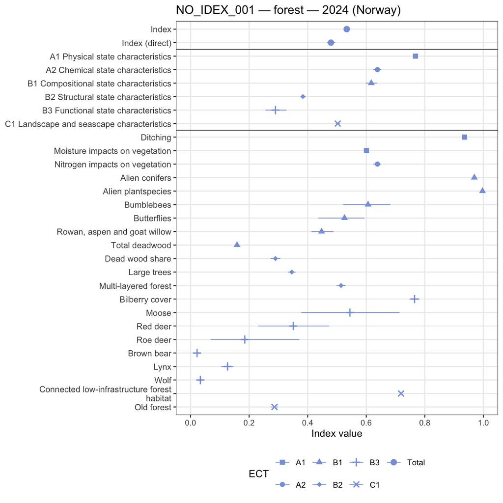

```r
for (yr in target_years) {
  print(plot_index_detailed(
    forest_index, yr,
    title = "NO_IDEX_001 — forest",
    national_only = TRUE,
    registry = registry_forest
  ))
}
```

### 4.2 Mountain

```r
index_figure_summary_table(
  mountain_index,
  registry_mountain,
  years = target_years,
  caption = "Mountain index — all areas and reporting years"
)
```

| Year | Area | Level | ECT | ID | Name | Median | 2.5% | 97.5% |
| --- | --- | --- | --- | --- | --- | --- | --- | --- |
| 2019 | C | Indicator | A1 | NO_GLAC_001 | Glaciers | 0.3379354781026475 | 0.3358726027280226 | 0.3398436557809556 |
| 2019 | C | Indicator | A1 | NO_SNOW_001 | Snow depth | 0.9376185920828882 | 0.6625374497527459 | 0.9929214251820974 |
| 2019 | C | Indicator | A1 | NO_FUHR_002 | Warming impact on vegetation | 0.3657306674554263 | 0.3181000367469685 | 0.4124896747637566 |
| 2019 | C | Indicator | B1 | NO_ALIE_002 | Alien plant species | 0.9996153846153846 | 0.9995652173913043 | 1 |
| 2019 | C | Indicator | B1 | NO_AFOX_001 | Arctic fox | 0.069738073305444 | 0.02112668925706793 | 0.1286971124368007 |
| 2019 | C | Indicator | B1 | NO_GOLD_001 | Golden eagle | 0.9056511890301115 | 0.6339390445722288 | 1 |
| 2019 | C | Indicator | B1 | NO_PTAR_001 | Ptarmigan | 0.5247129668865915 | 0.1824744869132543 | 0.8232390111194474 |
| 2019 | C | Indicator | B1 | NO_JERV_001 | Wolverine | 0.2418600936750125 | 0.2366412717108304 | 0.2474077378458145 |
| 2019 | C | Indicator | B2 | NO_LAVH_001 | Lichen biomass | 0.7377471943343975 | 0.7101998104719042 | 0.7615343698751196 |
| 2019 | C | Indicator | B3 | NO_SLIT_001 | Erosive disturbance | 0.9999999999805518 | 0.9788362960754987 | 1 |

[output cut: 190 more lines]

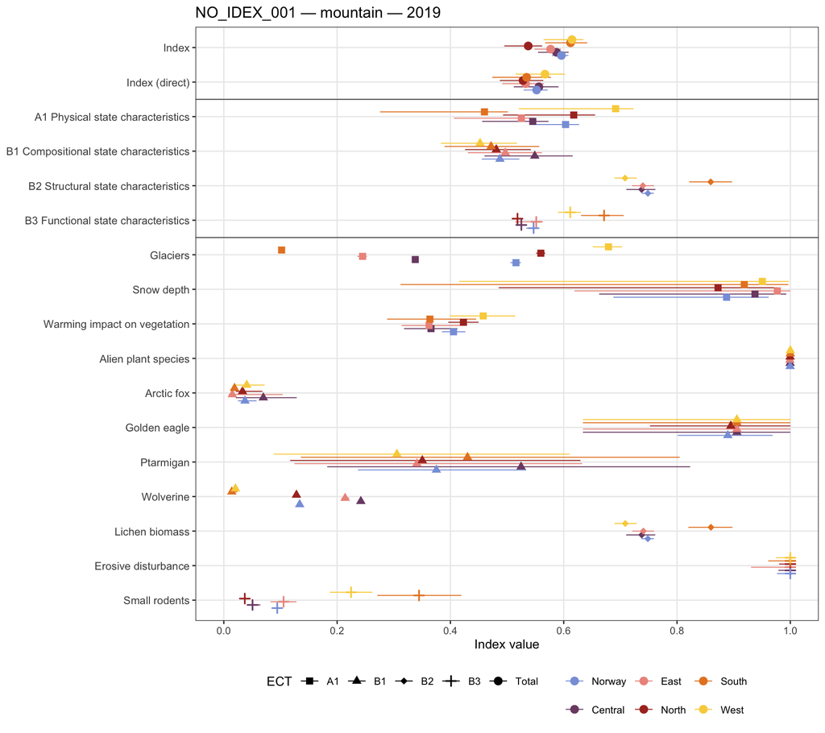

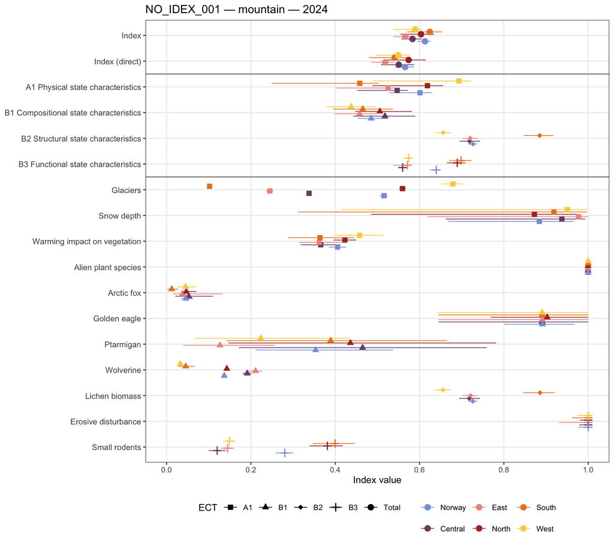

```r
for (yr in target_years) {
  print(plot_index_detailed(
    mountain_index, yr,
    title = "NO_IDEX_001 — mountain",
    registry = registry_mountain
  ))
}
```

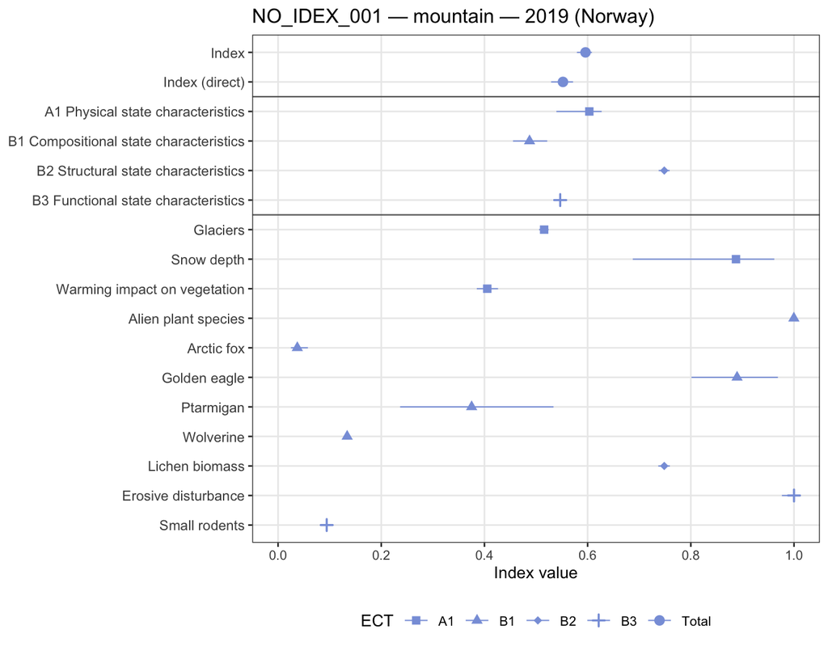

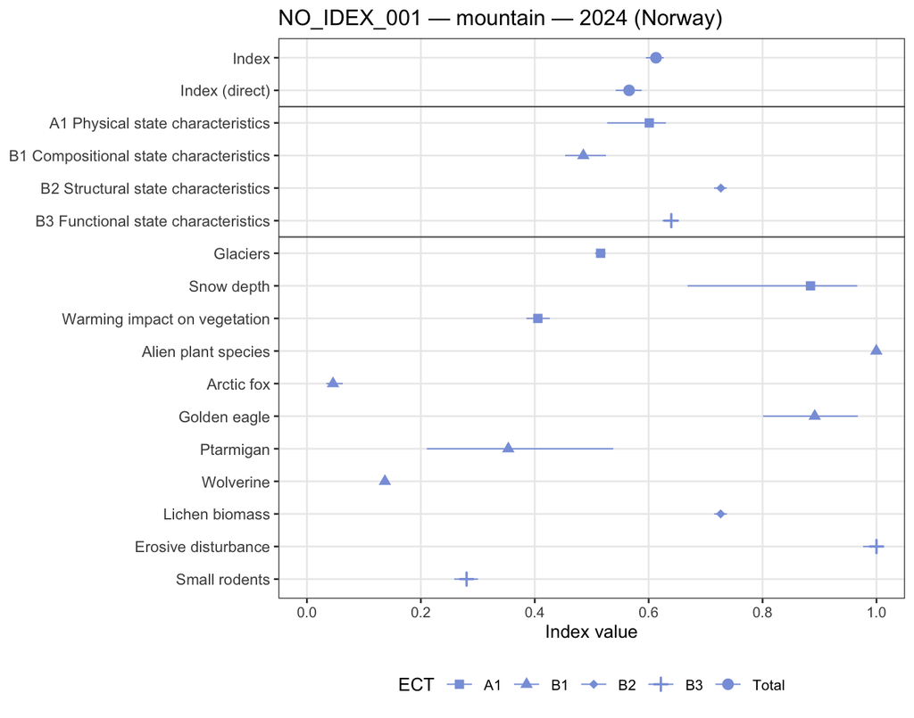

```r
for (yr in target_years) {
  print(plot_index_detailed(
    mountain_index, yr,
    title = "NO_IDEX_001 — mountain",
    national_only = TRUE,
    registry = registry_mountain
  ))
}
```

English and Norwegian versions of the same figures are also written to `img/` (not shown here) for reuse.

## 5. Export file

The exported files contain the full MC distributions for every level (`"ECT"`, `"Index"`, and the alternative `"Index (direct)"`, see Section 3), area, and year — identifiable via the `level` and `id` columns.

```r
export_index_results(
  forest_index$distributions,
  here("data/results_NO_IDEX_001_forest_v1.0.1.csv")
)

export_index_results(
  mountain_index$distributions,
  here("data/results_NO_IDEX_001_mountain_v1.0.1.csv")
)
```